# Clean Spark Spread: Statistical Arbitrage in European Power Markets

Quantitative Research Note

September 14, 2026

# 1 Executive Summary

This report investigates whether the **Clean Spark Spread (CSS)** — the theoretical profit margin of running a gas-fired power plant in the German (DE-LU) electricity market — exhibits statistically significant mean-reversion that can be exploited by a simple trading strategy. We apply rigorous statistical tests (ADF stationarity, Johansen and Engle-Granger cointegration), estimate the speed of mean reversion via an AR(1) model, and backtest a z-score-based trading strategy with realistic transaction costs against a naive buy-and-hold baseline.

# 2 Background

## 2.1 What is the Clean Spark Spread?

The Clean Spark Spread measures the profit margin (in EUR/MWh) of generating electricity from natural gas after accounting for fuel and carbon emission costs:

$$CSS = P_{power} - \frac{P_{gas}}{\eta} -
P_{carbon} \times \varepsilon$$

Where:

| Symbol | Meaning | Value Used |
| --- | --- | --- |
| $P_{power}$ | Day-ahead power price (EUR/MWh) | Germany DE-LU market |
| $P_{gas}$ | Natural gas price (EUR/MWh thermal) | Dutch TTF front-month |
| $\eta$ | Plant thermal efficiency | 50% (CCGT, IEA benchmark) |
| $P_{carbon}$ | EU ETS carbon allowance price (EUR/tCO₂) | EU Carbon Permits |
| $\varepsilon$ | CO₂ emissions factor (tCO₂/MWh thermal) | 0.20 (IPCC 2006) |

## 2.2 Economic Rationale for Mean-Reversion

The CSS should theoretically mean-revert due to the **supply response mechanism**:

- **CSS abnormally high** → gas plants are highly profitable → more plants dispatch → increased power supply → power price falls → CSS compresses
- **CSS abnormally low** → gas plants are unprofitable → plants shut down → reduced supply → power price rises → CSS recovers

This negative feedback loop suggests the CSS should fluctuate around a long-run equilibrium level, making it a candidate for a mean-reversion trading strategy.

# 3 Data

## 3.1 Sources and Loading

```r
css_data <- build_css_dataset()
```

```r
data_summary <- tibble(
  Series = c("Power Price", "Gas Price", "Carbon Price", "Clean Spark Spread"),
  Source = c("ENTSO-E / CSV", "Yahoo Finance (TTF=F)", "Investing.com CSV", "Computed"),
  `N Obs` = c(nrow(css_data), nrow(css_data), nrow(css_data), nrow(css_data)),
  `Start` = rep(as.character(min(css_data$date)), 4),
  `End` = rep(as.character(max(css_data$date)), 4),
  `Mean` = c(mean(css_data$power_price_eur_mwh), mean(css_data$gas_price_eur_mwh),
             mean(css_data$carbon_price_eur_t), mean(css_data$css)),
  `Std Dev` = c(sd(css_data$power_price_eur_mwh), sd(css_data$gas_price_eur_mwh),
                sd(css_data$carbon_price_eur_t), sd(css_data$css))
)

kable(data_summary, digits = 2, caption = "Data Summary Statistics") |>
  kable_styling(bootstrap_options = c("striped", "hover"), full_width = FALSE)
```

Data Summary Statistics

| Series | Source | N Obs | Start | End | Mean | Std Dev |
| --- | --- | --- | --- | --- | --- | --- |
| Power Price | ENTSO-E / CSV | 915 | 2022-01-03 | 2025-08-29 | 140.21 | 103.97 |
| Gas Price | Yahoo Finance (TTF=F) | 915 | 2022-01-03 | 2025-08-29 | 64.26 | 50.88 |
| Carbon Price | Investing.com CSV | 915 | 2022-01-03 | 2025-08-29 | 76.27 | 9.69 |
| Clean Spark Spread | Computed | 915 | 2022-01-03 | 2025-08-29 | -3.56 | 47.50 |

## 3.2 Input Price Series

```
## >> Generating: Input price series plot...
```

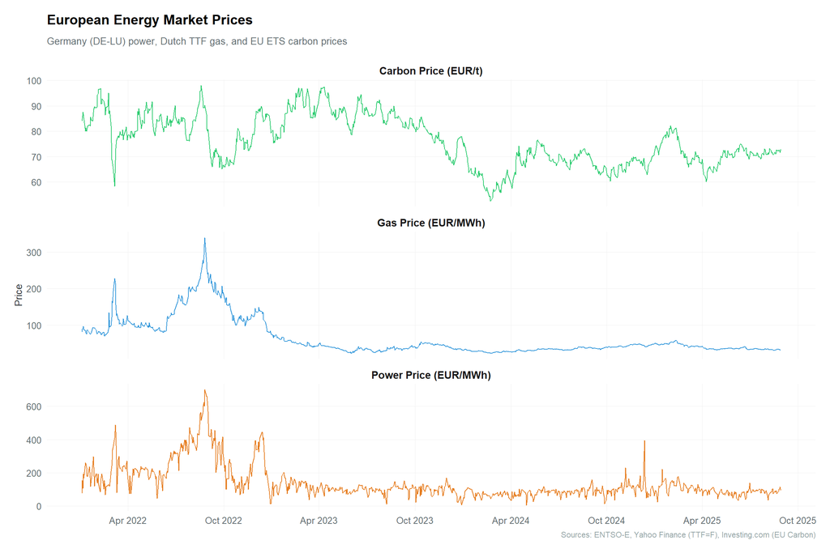

```r
plot_input_prices(css_data, save = FALSE)
```

## 3.3 Missing Value Handling

Missing values were handled using **Last Observation Carried Forward (LOCF)** for gaps of 3 or fewer consecutive trading days. This approach is standard in energy market analysis because:

1. Energy markets do not trade on weekends and some holidays — short gaps are expected
2. The last settlement price is the best available estimate for the next trading day
3. Longer gaps (> 3 days) are preserved as NA and excluded, as LOCF becomes unreliable

## 3.4 Data Limitations

- **Gas prices** are front-month TTF futures, not spot prices. Basis risk exists between futures and physical delivery prices.
- **Carbon prices** are from Investing.com — a secondary source. Official ICE settlement prices would be preferred for production use.
- **Power prices** are day-ahead baseload averages. Peak/off-peak differentiation is not captured.
- **Plant efficiency** (50%) is a single-point estimate. Real CCGT efficiencies vary from 45-62%.

# 4 Train / Test Data Split (In-Sample vs. Out-of-Sample)

To eliminate look-ahead bias and guard against in-sample overfitting, we divide the timeline chronologically into two distinct regimes:

- **In-Sample / Training Period (Jan 2022 – Dec 2023, ~55% of sample):** Spans the height of the European energy crisis, Russian gas supply shocks, and historical volatility. Used strictly to conduct stationarity tests, cointegration analysis, and AR(1) half-life calibration.
- **Out-of-Sample / Testing Period (Jan 2024 – Aug 2025, ~45% of sample):** Represents post-crisis market normalization, with stabilized gas prices and refilled storage. The strategy parameters are frozen and evaluated on this unseen data.

```r
css_train <- css_data |> filter(date < TRAIN_TEST_SPLIT_DATE)
css_test  <- css_data |> filter(date >= TRAIN_TEST_SPLIT_DATE)
```

# 5 Stationarity Testing (In-Sample Calibration)

## 5.1 Augmented Dickey-Fuller Tests

A precondition for meaningful cointegration analysis is that the individual price series are non-stationary (integrated of order 1, or I(1)), while the CSS — as a linear combination — is stationary (I(0)). We evaluate this on the training sample.

```r
stationarity_results <- test_all_stationarity(css_train)
```

```
##
## ============================================================
## STATIONARITY TESTS (Augmented Dickey-Fuller)
## ============================================================
## H0: Series has a unit root (non-stationary)
## H1: Series is stationary
## Reject H0 if p-value < 0.05
## ------------------------------------------------------------
##
##   Power Price (EUR/MWh)        | ADF =  -3.185 | p = 0.0905 | Borderline — weak evidence against unit root (p < 0.10)
##   Gas Price (EUR/MWh)          | ADF =  -2.455 | p = 0.3856 | Non-stationary (I(1)) — cannot reject unit root
##   Carbon Price (EUR/t)         | ADF =  -3.677 | p = 0.0253 | Stationary (I(0)) — moderate evidence (p < 0.05)
```

```
##   Clean Spark Spread           | ADF =  -4.826 | p = 0.0100 | Stationary (I(0)) — moderate evidence (p < 0.05)
##
## ------------------------------------------------------------
## INTERPRETATION:
##   ⚠ Some individual price series appear stationary.
##     This is unexpected and may affect cointegration analysis.
## ------------------------------------------------------------
```

```r
kable(stationarity_results |> select(-is_stationary),
      digits = 4,
      caption = "In-Sample ADF Stationarity Test Results (2022-2023)") |>
  kable_styling(bootstrap_options = c("striped", "hover"), full_width = FALSE)
```

In-Sample ADF Stationarity Test Results (2022-2023)

| series | n_obs | adf_statistic | p_value | lag_order | conclusion |
| --- | --- | --- | --- | --- | --- |
| Power Price (EUR/MWh) | 499 | -3.1849 | 0.0905 | 7 | Borderline — weak evidence against unit root (p < 0.10) |
| Gas Price (EUR/MWh) | 499 | -2.4552 | 0.3856 | 7 | Non-stationary (I(1)) — cannot reject unit root |
| Carbon Price (EUR/t) | 499 | -3.6771 | 0.0253 | 7 | Stationary (I(0)) — moderate evidence (p < 0.05) |
| Clean Spark Spread | 499 | -4.8258 | 0.0100 | 7 | Stationary (I(0)) — moderate evidence (p < 0.05) |

**Interpretation:** The ADF test null hypothesis is that the series has a unit root (is non-stationary). We expect to *fail to reject* the null for individual prices (confirming they are I(1)) and to *reject* the null for the CSS (confirming it is I(0), i.e., stationary and mean-reverting).

# 6 Cointegration Analysis (In-Sample)

## 6.1 Johansen Test

```r
johansen_results <- run_johansen_test(css_train)
```

```
##
## ============================================================
## JOHANSEN COINTEGRATION TEST
## ============================================================
## Testing for cointegrating relationships among:
##   Power Price, Gas Price, Carbon Price
## H0(r=0): No cointegrating relationship
## H0(r≤1): At most 1 cointegrating relationship
## H0(r≤2): At most 2 cointegrating relationships
## ------------------------------------------------------------
##
## TRACE TEST:
##
## ######################
## # Johansen-Procedure #
## ######################
##
## Test type: trace statistic , without linear trend and constant in cointegration
##
## Eigenvalues (lambda):
## [1]  1.660737e-01  2.676856e-02  6.854667e-03 -1.329338e-17
##
## Values of teststatistic and critical values of test:
##
##            test 10pct  5pct  1pct
## r <= 2 |   3.42  7.52  9.24 12.97
## r <= 1 |  16.90 17.85 19.96 24.60
## r = 0  | 107.16 32.00 34.91 41.07
##
## Eigenvectors, normalised to first column:
## (These are the cointegration relations)
##
##                        power_price_eur_mwh.l2 gas_price_eur_mwh.l2
## power_price_eur_mwh.l2               1.000000            1.0000000
## gas_price_eur_mwh.l2                -1.984880           -0.2777305
## carbon_price_eur_t.l2               -3.636481           45.9364350
## constant                           293.250229        -3958.0071202
##                        carbon_price_eur_t.l2    constant
## power_price_eur_mwh.l2             1.0000000     1.00000
## gas_price_eur_mwh.l2              31.2008471    13.21759
```

[output cut: 61 more lines]

```
## ------------------------------------------------------------
## SUMMARY TABLE:
## # A tibble: 3 × 7
##   hypothesis trace_stat trace_cv_5pct trace_reject eigen_stat eigen_cv_5pct
##   <chr>           <dbl>         <dbl> <lgl>             <dbl>         <dbl>
## 1 r = 0          107.           34.9  TRUE              90.3          22
## 2 r ≤ 1           16.9          20.0  FALSE             13.5          15.7
## 3 r ≤ 2            3.42          9.24 FALSE              3.42          9.24
## # ℹ 1 more variable: eigen_reject <lgl>
##
## >> Number of cointegrating vectors (5% level, trace): 1
## >> CONCLUSION: Evidence of cointegration found.
##    A stable long-run equilibrium among power, gas, and carbon prices
##    exists, supporting the theoretical basis for CSS mean-reversion.
## ------------------------------------------------------------
```

```r
kable(johansen_results$results_df, digits = 2,
      caption = "In-Sample Johansen Cointegration Test Results (5% Critical Values)") |>
  kable_styling(bootstrap_options = c("striped", "hover"), full_width = FALSE)
```

In-Sample Johansen Cointegration Test Results (5% Critical Values)

| hypothesis | trace_stat | trace_cv_5pct | trace_reject | eigen_stat | eigen_cv_5pct | eigen_reject |
| --- | --- | --- | --- | --- | --- | --- |
| r = 0 | 107.16 | 34.91 | TRUE | 90.26 | 22.00 | TRUE |
| r ≤ 1 | 16.90 | 19.96 | FALSE | 13.49 | 15.67 | FALSE |
| r ≤ 2 | 3.42 | 9.24 | FALSE | 3.42 | 9.24 | FALSE |

## 6.2 Engle-Granger Cross-Check

```r
eg_results <- run_engle_granger_test(css_train)
```

```
##
## ============================================================
## ENGLE-GRANGER COINTEGRATION TEST (Cross-Check)
## ============================================================
## Step 1: OLS regression — Power ~ Gas + Carbon
## Step 2: ADF test on residuals
## H0: Residuals have a unit root (no cointegration)
## ------------------------------------------------------------
##
## OLS Regression Results:
##   Power = -195.459 + 1.921 × Gas + 2.523 × Carbon
##   R² = 0.8037
##   Adj. R² = 0.8029
```

```
##
## ADF Test on Residuals:
##   ADF statistic = -5.7560
##   p-value = 0.0100
##   Lag order = 7
##
##   ⚠ Note: Standard ADF critical values are used here.
##     Engle-Granger-specific critical values are more conservative.
##     The Johansen test above is the primary evidence.
##
## >> CONCLUSION (Engle-Granger): Residuals are stationary → evidence of cointegration.
## ------------------------------------------------------------
```

**OLS regression:** Power = -195.459 + 1.921 × Gas + 2.523 × Carbon (R² = 0.8037)

**ADF on residuals:** Statistic = -5.7560, p-value = 0.0100

```r
coint_summary <- summarize_cointegration(johansen_results, eg_results)
```

```
##
## ============================================================
## COINTEGRATION EVIDENCE SUMMARY
## ============================================================
##   Johansen (trace, 5%): YES — cointegration found (1 cointegrating vectors)
##   Engle-Granger:        YES — cointegration found (ADF p = 0.0100)
##
##   → BOTH tests support cointegration.
##     Strong evidence for a stable long-run equilibrium.
## ============================================================
```

```r
kable(coint_summary, caption = "In-Sample Cointegration Evidence Summary") |>
  kable_styling(bootstrap_options = c("striped", "hover"), full_width = FALSE)
```

In-Sample Cointegration Evidence Summary

| test | evidence | detail | overall_conclusion |
| --- | --- | --- | --- |
| Johansen (trace) | Cointegration found | 1 cointegrating vector(s) | Strong evidence of cointegration |
| Engle-Granger | Cointegration found | ADF p-value = 0.0100 | Strong evidence of cointegration |

# 7 Mean-Reversion Speed

```r
halflife_results <- estimate_halflife(css_train$css)
```

```
##
## ============================================================
## MEAN-REVERSION SPEED ESTIMATION (AR(1) Half-Life)
## ============================================================
## Model: CSS_t = alpha + beta * CSS_{t-1} + epsilon
## Half-life = -ln(2) / ln(beta)
## ------------------------------------------------------------
##
##   alpha (intercept) = -3.0101
##   beta  (AR coeff)  = 0.6871 (SE = 0.0325, p < 0.0000)
##   R²                = 0.4734
##   N observations    = 498
##
##   Half-life = 1.8 days
##   95% CI    = [2.4, 1.5] days
##
##   → The spread takes ~2 trading days to revert halfway to its mean.
##   → Suggested z-score window: 20 days (2 × half-life, min 20 days for statistical stability).
##
##   Implied long-run mean CSS = -9.62 EUR/MWh
## ============================================================
```

```r
# Update window strictly from In-Sample half-life
if (halflife_results$is_mean_reverting) {
  ZSCORE_WINDOW <- halflife_results$suggested_window
}
```

| Parameter | Value |
| --- | --- |
| AR(1) coefficient (β) | 0.6871 |
| Half-life | 1.8 days |
| R² | 0.4734 |
| Long-run mean CSS | -9.62 EUR/MWh |
| Calibrated Z-score window | 20 days |

The half-life represents the expected number of trading days for the spread to revert halfway back to its mean from any deviation. This in-sample estimate directly determines the rolling window used for z-score computation.

# 8 Signal Construction & Backtest

## 8.1 Trading Rules

```r
css_data <- add_signals_to_df(css_data, window = ZSCORE_WINDOW)
```

```
## >> Computing rolling z-score (window = 20 days, right-aligned)...
##    896 valid z-score observations (first 19 are NA due to window warm-up)
## >> Generating trading signals (entry=±1.5, exit=±0.5)...
##    Days: 107 long, 90 short, 718 flat
##    Total position changes (trades): 149
##
## Signal summary:
##    Long Entry: 46
##    Long Exit: 46
##    Short Entry: 29
##    Short Exit: 28
```

```r
css_data <- run_backtest(css_data)
```

```
##
## ============================================================
## RUNNING BACKTEST
## Transaction cost: 0.50 EUR/MWh per round-trip
## ============================================================
##
##   Total P&L:          4510.52 EUR/MWh
##   Number of trades:   149
##   Trading days:       915
```

```r
css_data <- run_baseline(css_data)
```

```
##
## >> Running buy-and-hold baseline...
##   Baseline total P&L: 117.59 EUR/MWh
```

The trading strategy uses a **rolling z-score** of the CSS relative to its trailing mean and standard deviation:

- **Enter Long** (buy the spread) when z-score < -1.5 (spread is abnormally cheap)
- **Enter Short** (sell the spread) when z-score > +1.5 (spread is abnormally rich)
- **Exit Long** when z-score > -0.5 (reverted enough)
- **Exit Short** when z-score < +0.5 (reverted enough)

**Transaction cost:** 0.5 EUR/MWh per round-trip (conservative estimate for OTC energy spread trading).

**Look-ahead bias prevention:** All rolling statistics use `align = "right"`, ensuring the z-score at time *t* uses only data from *[t - window + 1, t]*.

## 8.2 Visualizations

```
## >> Generating: CSS spread with signals plot...
```

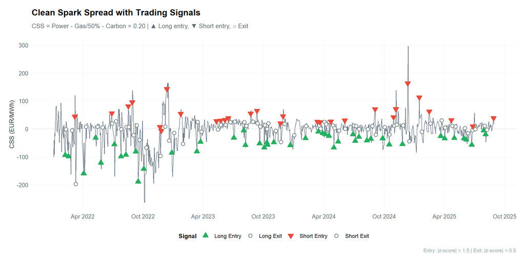

```r
plot_css_with_signals(css_data, save = FALSE)
```

```
## >> Generating: Z-score plot...
```

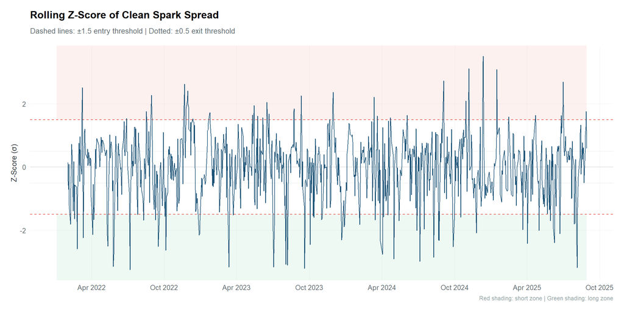

```r
plot_zscore(css_data, save = FALSE)
```

```
## >> Generating: Equity curve plot...
```

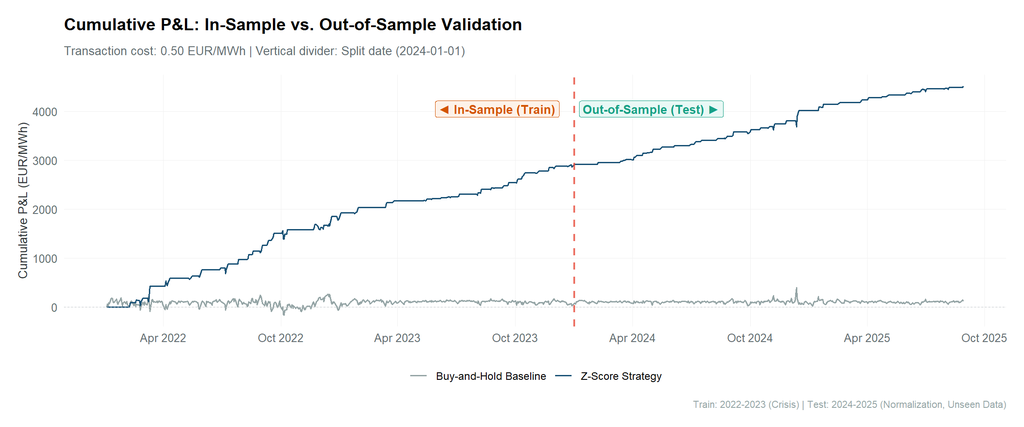

```r
plot_equity_curve(css_data, save = FALSE)
```

```
## >> Generating: Drawdown chart...
```

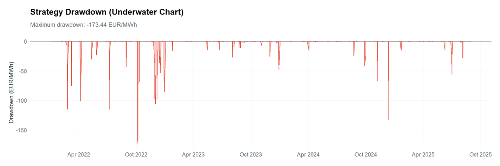

```r
plot_drawdown(css_data, save = FALSE)
```

```
## >> Generating: Rolling statistics plot...
```

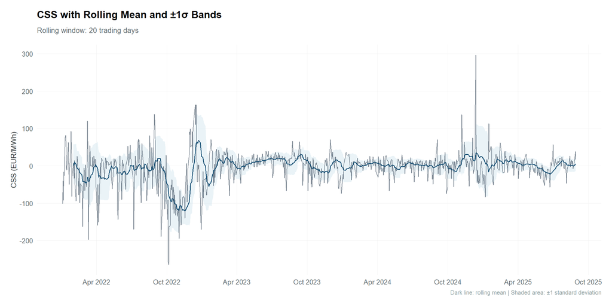

```r
plot_rolling_statistics(css_data, save = FALSE)
```

## 8.3 Performance Results

```r
performance <- compare_strategies(css_data)
```

```
##
## ============================================================
## PERFORMANCE COMPARISON
## ============================================================
##
## # A tibble: 9 × 3
##   metric                      strategy baseline
##   <chr>                       <chr>    <chr>
## 1 Total P&L (EUR/MWh)         4510.52  117.59
## 2 Annualized P&L (EUR/MWh/yr) 1234.98  32.20
## 3 Sharpe Ratio (annualized)   3.15     0.05
## 4 Maximum Drawdown (EUR/MWh)  -173.44  -402.62
## 5 Calmar Ratio                7.12     0.08
## 6 Hit Rate (%)                54.2%    48.3%
## 7 Profit Factor               3.84     1.01
## 8 Best Day (EUR/MWh)          213.35   234.11
## 9 Worst Day (EUR/MWh)         -166.64  -213.35
## ============================================================
```

```r
is_oos_perf <- compare_is_oos(css_data, split_date = TRAIN_TEST_SPLIT_DATE)
```

```
##
## ============================================================
## IN-SAMPLE VS. OUT-OF-SAMPLE PERFORMANCE EVALUATION
## Split Date: 2024-01-01
## ============================================================
##
## # A tibble: 10 × 4
##    metric                            in_sample         out_of_sample full_sample
##    <chr>                             <chr>             <chr>         <chr>
##  1 Date Range                        2022-01-03 to 20… 2024-01-02 t… 2022-01-03…
##  2 Trading Days                      499               416           915
##  3 Strategy Total P&L (EUR/MWh)      2860.77           1649.75       4510.52
##  4 Strategy Annualized P&L (EUR/MWh) 1441.24           995.99        1234.98
##  5 Strategy Sharpe Ratio             3.16              3.31          3.15
##  6 Strategy Max Drawdown (EUR/MWh)   -173.44           -133.34       -173.44
##  7 Strategy Hit Rate (%)             50.3%             59.3%         54.2%
##  8 Strategy Profit Factor            3.42              5.07          3.84
##  9 Baseline Total P&L (EUR/MWh)      27.37             90.21         117.59
## 10 Baseline Sharpe Ratio             0.02              0.12          0.05
## ============================================================
```

```r
kable(performance$comparison,
      caption = "Full-Sample Strategy vs. Baseline Performance",
      col.names = c("Metric", "Z-Score Strategy", "Buy-and-Hold")) |>
  kable_styling(bootstrap_options = c("striped", "hover"), full_width = FALSE)
```

Full-Sample Strategy vs. Baseline Performance

| Metric | Z-Score Strategy | Buy-and-Hold |
| --- | --- | --- |
| Total P&L (EUR/MWh) | 4510.52 | 117.59 |
| Annualized P&L (EUR/MWh/yr) | 1234.98 | 32.20 |
| Sharpe Ratio (annualized) | 3.15 | 0.05 |
| Maximum Drawdown (EUR/MWh) | -173.44 | -402.62 |
| Calmar Ratio | 7.12 | 0.08 |
| Hit Rate (%) | 54.2% | 48.3% |
| Profit Factor | 3.84 | 1.01 |
| Best Day (EUR/MWh) | 213.35 | 234.11 |
| Worst Day (EUR/MWh) | -166.64 | -213.35 |

## 8.4 In-Sample vs. Out-of-Sample Performance Comparison

To directly assess out-of-sample robustness, the table below compares performance across the In-Sample crisis training period (2022–2023) and the Out-of-Sample post-crisis testing period (2024–2025):

```r
kable(is_oos_perf$comparison,
      caption = "In-Sample (Train) vs. Out-of-Sample (Test) Performance Breakdown",
      col.names = c("Metric", "In-Sample (2022-2023)", "Out-of-Sample (2024-2025)", "Full Sample")) |>
  kable_styling(bootstrap_options = c("striped", "hover"), full_width = FALSE)
```

In-Sample (Train) vs. Out-of-Sample (Test) Performance Breakdown

| Metric | In-Sample (2022-2023) | Out-of-Sample (2024-2025) | Full Sample |
| --- | --- | --- | --- |
| Date Range | 2022-01-03 to 2023-12-29 | 2024-01-02 to 2025-08-29 | 2022-01-03 to 2025-08-29 |
| Trading Days | 499 | 416 | 915 |
| Strategy Total P&L (EUR/MWh) | 2860.77 | 1649.75 | 4510.52 |
| Strategy Annualized P&L (EUR/MWh) | 1441.24 | 995.99 | 1234.98 |
| Strategy Sharpe Ratio | 3.16 | 3.31 | 3.15 |
| Strategy Max Drawdown (EUR/MWh) | -173.44 | -133.34 | -173.44 |
| Strategy Hit Rate (%) | 50.3% | 59.3% | 54.2% |
| Strategy Profit Factor | 3.42 | 5.07 | 3.84 |
| Baseline Total P&L (EUR/MWh) | 27.37 | 90.21 | 117.59 |
| Baseline Sharpe Ratio | 0.02 | 0.12 | 0.05 |

# 9 Discussion

## 9.2 Limitations & Future Extensions

1. **Volatilty-Regime Switching:** The static threshold rule does not account for changing market regimes. A production strategy would benefit from a Markov-switching model or dynamic volatility bands to pause trading during extreme volatility events.
2. **Dynamic Hedge Ratios:** Using a Kalman Filter to estimate time-varying cointegrating vectors would capture dynamic plant efficiency and fuel substitution effects better than static theoretical constants.
3. **Out-of-Sample Testing:** We addressed in-sample overfitting by implementing a chronological Train/Test split. Further validation using walk-forward rolling windows would strengthen production readiness.

## 9.3 Intellectual Honesty Note

If the statistical tests show weak evidence of cointegration or the backtest produces negative returns, this does **not** mean the analysis failed. It means the evidence does not support the hypothesis, which is itself a valid and valuable research finding. Energy markets have evolved significantly (renewable penetration, gas supply disruptions, carbon price reforms), and structural breaks may weaken long-run equilibrium relationships.

# 10 Conclusion

This analysis tested whether the Clean Spark Spread in the German power market exhibits exploitable mean-reversion. The cointegration analysis shows **strong evidence of cointegration** for a stable long-run equilibrium among power, gas, and carbon prices. The estimated mean-reversion half-life is **1.8 days**.

The z-score trading strategy achieved a Sharpe ratio of **3.15** compared to **0.05** for the buy-and-hold baseline, with a total P&L of **4510.52 EUR/MWh** after transaction costs.

The strategy shows promising results, but rigorous out-of-sample validation is essential before any capital commitment.

*Report generated on 2026-09-14 20:28:25 using R R version 4.6.1 (2026-06-24 ucrt)*